# Exporting contracts data from Mexico

Alonso Hidalgo Latin America Associate @NRGI

2018-11-20

# 1 Background:

In 2014 Mexico commited to implement EITI as part of the OGP its action plan. From this point on they have made several advances towards fully adhering to the initiative. One of the main innovations comming from the Mexican experience is the publishing of an EITI portal that will function as a “one stop shop” to EITI data.

# 2 Methodology

## 2.1 Load data

### 2.1.2 Loading the data to R environment

The code below loads the EITI data and the RC template that we need to populate

```r
### Remove all objets from evironment and upload all the libraries requiered
rm(list = ls())
library(tidyverse); library(readxl); library(lubridate); library(ggplot2); library(tidyr); library(sf); library(rnaturalearth)
### Load EITI Mexico Data
eitiImport <- read_csv(url("http://eiti.transparenciapresupuestaria.gob.mx/es/eiti/ficha_recurso/_rid/13/_mto/3/_mod/descargar?tipo=recurso_csv&id=4"), locale = locale(encoding = "latin1"))
### Load Resource Contracts template for MEX
rcMXdata <- read_csv("data/ResourceContractsMX.csv")
```

The goal of this file is to convert the large EITI data import file into multiple tidy relational tables.

The EITI data is at level of contract IDs. Each contract ID can have multiple companies associated with it. Currently the companies are kept together in a single row using separators like ‘y’, ‘,’, ‘.,’ etc. Our first table splits these companies each into a separate row to create a new contract dataset that contains multiple rows for each contract ID that capture the different companies associated with it.

### 2.1.3 Problem

We assumed that the contract IDs are unique. However, this is not the case. There is a contract id that repeates itself in the data. This is most likely a human error. To solve this we need to concatenate the name of the state and the contract id. We have to do this so we can proceed with separating company names.

**Note**: This is not foolproof. For instance, if we have a data error where the contract id repeats within the same state, this will not work. We need to come up with a better in the future.

```r
eitiImport <- eitiImport %>%
  dplyr::rename(contractID = ID_CONTRATO, companyName = DESC_ORGANIZACION) %>%
  group_by(contractID) %>%
  mutate(nObs = n()) %>%
  ungroup() %>%
  mutate(contractIDNew = if_else(nObs > 1, paste (contractID, ENTIDAD_FEDERATIVA_ENTREGA_ITEMS_PROCED , sep = "-"), contractID))
#create a table that maps old id with new
idMapping <-  eitiImport %>%
  select(contractIDOld = contractID, contractIDNew)
##update the table with unique contract ids that were created in the previous step
eitiImport <- eitiImport %>%
  select(-contractID, contractID = contractIDNew)
```

## 2.2 Creating our Main Table

```r
mainTable <- eitiImport %>%
  mutate(companyName = str_replace_all(companyName,
                                       c("Exploracion y Extraccion" = "Exploración & Extracción",
                                       "Exploración y Producción" = "Exploración & Producción",
                                       "Exploración y Extracción" = "Exploración & Extracción",
                                       "Corp., " = "Corp, ",
                                       ", S\\." = " S\\."))) %>%
  #the ", y" separator is used everytime two companies with property regime extentions appear together
  separate_rows(., companyName , sep = ", y ") %>%
  #the ", y" separator is used everytime two companies with property regime extentions appear together and if the second company has a name that begins with letter I
  separate_rows(., companyName , sep = ", e ") %>%
  #the "\\.," separator is used everytime more than two companies with property regime extensions appear together
  separate_rows(., companyName, sep = "\\., ") %>%
  #the " y " separator is used everytime two companies without property regime extensions appear together
  separate_rows(., companyName, sep = " y ") %>%
  #the ", " separator appears everytime more than two companies without property regime appear together
  separate_rows(., companyName, sep = ", ") %>%
  select(contractID, companyName) %>%
  mutate(participationShare = NA,
         projIdentifier = NA,
         licenseID = NA)
  #Replace the old company names with the new clean values
```

### 2.2.1 Data checks

The code above separates the company names. However, we need to check to see if this was done correctly. To do so we, combine the original company names with the splits to see if this was done correctly.

```r
joinNames <- left_join(eitiImport, mainTable, by = "contractID") %>%
  write_csv(., "data/check splits.csv")
```

In our case the splits with code were done correctly.

The next task is to reconcile company names. We do that manually and load as .csv file.

```r
mainTable <- left_join(mainTable, read_csv("data/cleanNames2.csv"), by = c("companyName" = "companyName.sep")) %>%
  select(-companyName, companyName = companyNameClean)
```

Next step manually reconcile company names. There are cases were different names are used for the same company, these need to be corrected so that they are called the same.

## 2.3 Creating the tidy Oil table

```r
tidyOil <- mainTable %>%
  #First we group the data frame by contract ID values. This will allow us to summarise the company names into single row.
  group_by(contractID) %>%
  summarise(contractName = paste(companyName, collapse = "; ")) %>%
  #Next we leftjoin the values we are interested in from the eiti data with the company names. The key is contract ID
  left_join(., eitiImport %>%
  select ( contractID ,
           docURL = URL_DOCUMENTO_CONTRATO,
           contractType = DESC_TIPO_CONTRATO,
           signatureDate = FECHA_FIRMA_CONTRATO,
           urlContract = URL_LOCALIZACION_ITEMS_CONTRATO,
           contractStatus = DETALLE_ESTATUS_CONTRATO,
           contractDuration = DURACION_DIAS_CONTRATO,
           lon = COORDENADAS_DETALLE_1,
           lat = COORDENADAS_DETALLE_2,
           area = SUPERFICIE,
           state =  ENTIDAD_FEDERATIVA_ENTREGA_ITEMS_PROCED,
           municipality =   MUNICIPIO_ENTREGA_ITEMS_PROCED),
  by = "contractID") %>%
  #Finally we create a new column with the mutate command. We are pasting the contract names with the contract ID and the signature year. This will be our contract name
  mutate(contractName = paste (contractName,contractID,year(ymd(signatureDate)), sep = "; "))
```

## 2.4 Creating the company grouping

```r
companyGrouping <- eitiImport %>%
  distinct(companyGroupID = ID_ADICIONAL_ORGANIZACION,
           companyName = companyName,
           companyCountry = PAIS_ORGANIZACION)
```

## 2.5 Making maps

Explore the sf package (just read the intro)

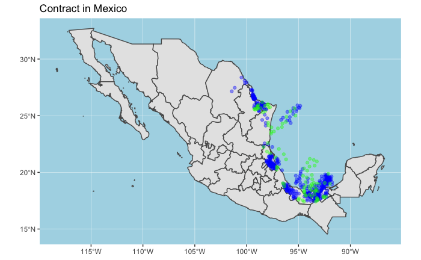

```r
#Load the sf state map of mexico
mexSF <-  ne_states(country = 'mexico', returnclass = "sf")
#use the lat lon coordinates in tidy oil to create a sf object
contract_map <- st_as_sf(tidyOil, coords = c("lon","lat"), crs = st_crs(mexSF))
mapColor <- str_detect(contract_map$contractName, "Pemex") %>%
  if_else(., "blue", "green")
#use geom_sf() to plot the base mexico map
ggplot() +
  geom_sf(data = mexSF) +
  geom_sf(data = contract_map, alpha = 0.4, color = mapColor) +
  labs(title = "Contract in Mexico") +
  theme(
    panel.background = element_rect(fill = "lightblue")
  )
```

# 3 Create a mining table

```r
#upload mining datasets
mexMining <- read_csv(url("https://eiti.transparenciapresupuestaria.gob.mx/es/eiti/ficha_recurso/_rid/13/_mto/3/_mod/descargar?tipo=recurso_csv&id=7"), locale = locale(encoding = "latin1"))
minindd <- read_csv(url("https://eiti.transparenciapresupuestaria.gob.mx/es/eiti/ficha_recurso/_rid/13/_mto/3/_mod/descargar?tipo=recurso_diccionario&id=7"), locale = locale(encoding = "latin1"))
#run checks: ids correspond to individual vaules
length(unique(mexMining$ID_CONTRATO))
```

```
[1] 25072
```

```r
uniqueIDs <- mexMining %>%
  select(ID_CONTRATO, DESC_ORGANIZACION) %>%
  group_by(ID_CONTRATO) %>%
  mutate(nobsM = n())

unique(uniqueIDs$nobsM)
```

```
[1] 1
```

```r
#now that we know that we have individual contract id values we can run the same lines of code we applied for hydrocarbons to create a mining tidy table
tidyMining <- mexMining %>%
  select ( contractID = ID_CONTRATO ,
           companyName = DESC_ORGANIZACION,
           docURL = URL_DOCUMENTO_CONTRATO,
           contractType = DESC_TIPO_CONTRATO,
           signatureDate = FECHA_FIRMA_CONTRATO,
           urlContract = URL_LOCALIZACION_ITEMS_CONTRATO,
           contractStatus = DETALLE_ESTATUS_CONTRATO,
           contractDuration = DURACION_DIAS_CONTRATO,
           lon = COORDENADAS_DETALLE_1,
           lat = COORDENADAS_DETALLE_2,
           area = SUPERFICIE,
           state =  ENTIDAD_FEDERATIVA_ENTREGA_ITEMS_PROCED,
           municipality =   MUNICIPIO_ENTREGA_ITEMS_PROCED) %>%
  mutate(companyName = str_replace_all(companyName,
                                       c( ", S." = "\\,S." ))) %>%
  separate_rows(., companyName , sep = ", ")
```